BACK TO MAIN MENU

- The Chi-Square Distribution
- The Goodness-of-fit Test
- Testing for Independence

# The Chi-Square Distribution

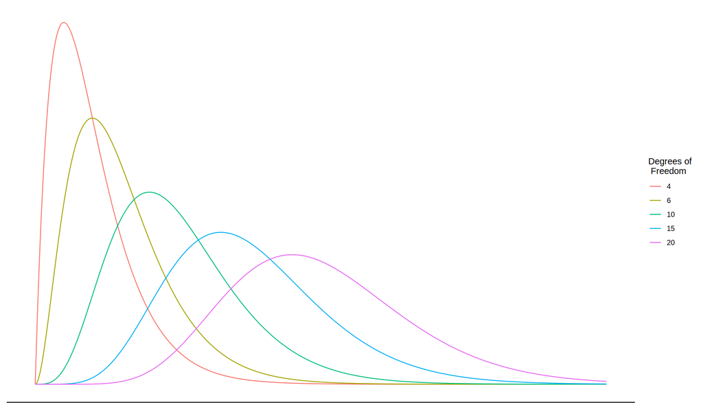

- The Chi-Square distribution is defined for positive values and its shape depends on the number of degrees of freedom.
- The Chi-Square distribution is not symmetric. It is skewed to the right.
- In this section, we find right-tail critical values for the Chi-Square distribution.

**Chi-Square Distribution with degrees of freedom 5**

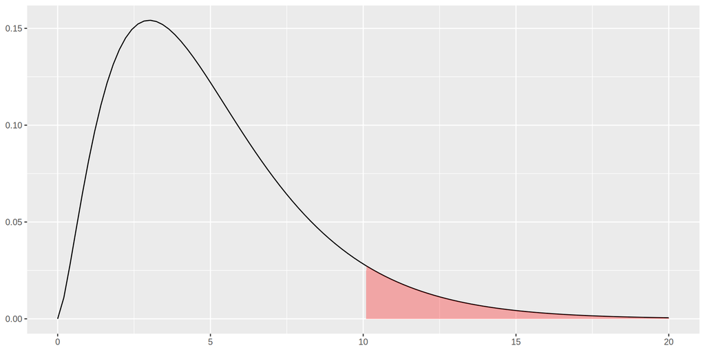

Suppose that $\chi^2$ follows a chi-square distribution with 8 degrees of freedom. Use the ALEKS calculator to answer the following.

*a)* Compute $P(\chi^2 \leq 4)$. Round your answer to at least three decimals places.

- In ALEKS calculator, the function $P(\chi^2 > ... )$ finds the probability of above the number (right tail).
- Therefore, $P(\chi^2 \leq 4)$ = 1 - $P(\chi^2 > 4)$
- In ALEKS calculator, compute 1 - $P(\chi^2 > 4$ with df=8)
- Answer = 0.14287653952 $\approx$ 0.143

*b)* Find k such that $P(\chi^2 \geq k)$ = 0.1. Round your answer to at least two decimals places.

- In ALEKS calculator, use the function $\chi^2$_
- Type $\chi^2_{0.1; df=8}$
- Answer = 13.361566137 $\approx$ 13.36

# The Goodness-of-fit Test

**Notation:**

- k = Number of categories (or levels) of a categorical variable.
- $p_1$ = True proportion for category 1
- $p_2$ = True proportion for category 2
- ….. $p_k$ = True proportion for category k
- By definition: $p_1 + p_2 + .... + p_k$ = 1
- Ho: $p_1$ = $po_1$; $p_2$ = $po_2$; ….; $p_k$ = $po_k$
- $H_1$: Ho is not true. At least one of the true category proportions differs from the corresponding hypothesized values.

> The goodness-of-fit statistic, denoted $X^2$, is a quantitative measure of the extent to which the observed counts differ from those expected when Ho is true.

> $X^2 = \sum_{i=1}^k \frac{(O_i - E_i)^2}{E_i}$, where n = Sample size, $O_i$: Observed count, $E_i$: Expected count = $n(po_i$), i = 1, 2, …, k

> When the null hypothesis is true and the sample size is sufficiently large, the behavior of $X^2$ is described approximately by a **chi-square distribution** with (k - 1) degrees of freedom.

> The chi-square distribution has no area associated with negative values and is asymmetric, with a longer tail on the right. The chi-square is identified with a different number of degrees of freedom.

**Exercise:** Are birthdays “evenly distributed” throughout the year, or are they more common during some parts of the year than others? Owners of a children’s toy store chain in the Northwest asked just this question. Some data collected by the chain are summarized in the table below.

The data were obtained from a random sample of 200 people. The birth date of each person was recorded, and each of these dates was placed into one of four categories: winter (December 21-March 20), spring (March 21-June 20), summer (June 21-September 20), and fall (September 21-December 20). The numbers in the first row of the table are the frequencies observed in the sample for these season categories. The numbers in the second row are the expected frequencies under the assumption that birthdays are equally likely during each season of the year. The bottom row of numbers gives the following value for each of the season categories.

$\frac{(f_o - f_e)^2}{f_e} = \frac{(Observed - Expected)^2}{Expected}$

**Part 1**

Fill in the missing values in the table. Round your responses for the expected frequencies to two or more decimal places. Round your $\frac{(f_o - f_e)^2}{f_e}$ responses to three or more decimal places.

| . | Winter | Spring | Summer | Fall | Total |
| --- | --- | --- | --- | --- | --- |
| Observed, $f_o$ | 33 | 44 | 64 | 59 | 200 |
| Expected, $f_e$ | - | 50 | 50 | - | - |
| $\frac{(f_o - f_e)^2}{f_e}$ | - | 0.720 | 3.920 | - | - |

Are birthdays “evenly distributed” throughout the year, or are they more common during some parts of the year than others?

- Ho: $p_w = p_s = p_r = p_f = 0.25$
- By definition, $f_e$ = $(N)(p_o)$
- $f_e$ = (200)(0.25) = 50
- Winter: $\frac{(f_o - f_e)^2}{f_e}$ = $\frac{(33 - 50)^2}{50}$ = 5.78
- Fall: $\frac{(f_o - f_e)^2}{f_e}$ = $\frac{(59 - 50)^2}{50}$ = 1.62

| . | Winter | Spring | Summer | Fall | Total |
| --- | --- | --- | --- | --- | --- |
| Observed, $f_o$ | 33 | 44 | 64 | 59 | 200 |
| Expected, $f_e$ | 50 | 50 | 50 | 50 | - |
| $\frac{(f_o - f_e)^2}{f_e}$ | 5.78 | 0.720 | 3.920 | 1.62 | - |

**Part 2**

Answer the following to summarize the test of the hypothesis that birthdays are equally likely during each season of the year. Use the 0.05 level of significance for the test.

*a)* Determine the type of test statistic to use.

- Chi-square. All expected frequencies at least 5.
- Degrees of freedom (k - 1) = 4 - 1 = 3

*b)* Find the value of the test statistic. (Round your answer to two or more decimal places.)

- $\sum \frac{(f_o - f_e)^2}{f_e}$
- 5.78 + 0.72 + 3.92 + 1.62 = **12.04**

*c)* Find the critical value. (Round your answer to two or more decimal places.)

- In ALEKS calculator, use the function $\chi^2$
- Run $\chi^2_{0.05; df=3}$
- Answer = 7.8147279034 $\approx$ 7.81

*d)* Can we reject the hypothesis that birthdays are equally likely during each season of the year?

- Identify rejection region: $[7.81, \infty)$
- Since 12.04 $\in$ $[7.81, \infty)$, reject Ho.

# Testing for Independence

**Do some college majors require more studying than others?**

The National Survey of Student Engagement asked a number of college freshmen what their major was and how many hours per week the spent studying, on average. A sample of 1000 pf these students was chosen, and the number of students in each category are presented in the **contingency table** below:

| Hours per week | Humanities | Social Science | Business | Engineering |
| --- | --- | --- | --- | --- |
| 0 - 10 | 68 | 106 | 131 | 40 |
| 11 - 20 | 119 | 103 | 127 | 81 |
| More than 20 | 70 | 52 | 51 | 52 |

A contingency table relates two **qualitative variables.**

One of the variables, called the *row variable*, has one category for each row of the table. The other variable, called the *column variable*, has one category for each column in the table.

The intersection of a row and a column is called a **cell**. For example, the number 68 appears in the upper left cell, which tell us that 68 students were humanities major who study 0 - 10 hours per week.

### Performing a test of Independence

We are interested in determining whether the distribution of one variable differs, depending on the value of the other variable. If so, the variables are **dependent**.

If the distribution of one variable is the **same** for all the values of the other variable, the variables are **independent**.

> Ho: Hours studying and major are independent

> $H_1$: Hours studying and major are not independent.

We use the chi-square statistic, $\chi^2$, to test the null hypothesis that major and hours of studying are independent.

> $\chi^2 = \sum \frac{(O - E)^2}{E}$

Where O is the observed frequency and E the expected frequency.

> E = $\frac{Row_{total} . Column_{total}}{Grand_{total}}$

For the given level of significance, $\alpha$, find the critical value from a Chi-Square distribution with (r -1)(c - 1) degrees of freedom, where *r* is the number of rows and *c* is the number of columns in the contingency table.

If the test statistic, $\chi^2$, is greater than or equal to the critical value, reject Ho. Otherwise, do not reject Ho.

> Step 1: Find the total rows and columns if there are not given.

| Hours per week | Humanities | Social Science | Business | Engineering | **Total** |
| --- | --- | --- | --- | --- | --- |
| 0 - 10 | 68 | 106 | 131 | 40 | **345** |
| 11 - 20 | 119 | 103 | 127 | 81 | **430** |
| More than 20 | 70 | 52 | 51 | 52 | **225** |
| **Total** | **257** | **261** | **309** | **173** | **1000** |

> Step 2: Compute the expected counts, E.

[output not shown]

> Step 3: Compute the squared residuals $\frac{(O - E)^2}{E}$

| Hours per week | Humanities | Social Science | Business | Engineering |
| --- | --- | --- | --- | --- |
| 0 - 10 | 4.816 | 2.827 | 5.582 | 6.492 |
| 11 - 20 | 0.652 | 0.759 | 0.259 | 0.587 |
| More than 20 | 2.563 | 0.770 | 4.936 | 4.392 |

> In the first cell, $\frac{(68 - 88.67)^2}{88.67}$ = 4.816

> Step 4: Compute the Chi-Square test statistic

> 4.816 + 2.827 + …. + 4.936 + 4.392 = **34.638**

> Test with level of significance of 5% and df = 2 x 3 = 6

> Step 5a (Critical value method):

> In ALEKS: $\chi^2_{0.05; df = 6}$ = 12.592

> Step 5b (P-value method):

> In ALEKS: P($\chi^2$ > 34.638 with df = 6) $\approx$ 0.0000051

> Step 6: State your conclusion.

> Using the Critical value method, reject Ho because test statistic, 34.638 is greater than 12.592.

> Using the P-value method, reject Ho because P-value is less than 5%.

> Therefore, there is enough evidence to suggest that hours of studying and major are not independent.